# Predictive gene selection in asthma

Damir Zhakparov

14 September 2026

# 1 Introduction

GeneSelectR combines repeated gene inclusion and excluded-sample predictive contribution into a ranking. Both components are compared with shuffled-outcome references. The output retains individual component measurements for inspection. The `SummarizedExperiment` input supports use with Bioconductor expression analysis tools. External biological information is interpreted after selection.

The example uses a small, deterministic subset of GSE69683, a U-BIOPRED blood expression study. It illustrates the software interface. It does not reproduce the full asthma benchmark or provide a new estimate of clinical performance.

# 2 Installation

The package is being prepared for submission. Install a local source archive before running this vignette. After Bioconductor acceptance, installation will use:

```r
BiocManager::install("GeneSelectR2")
```

# 3 Expression and phenotype

```r
library(GeneSelectR2)
library(SummarizedExperiment)
data(asthma_example)
dim(asthma_example)
```

```
#> [1] 300  96
```

```r
table(asthma_example$severity)
```

```
#>
#> moderate   severe
#>       48       48
```

```r
metadata(asthma_example)
```

```
#> $accession
#> [1] "GSE69683"
#>
#> $platform
#> [1] "GPL13158"
#>
#> $source
#> [1] "https://www.ncbi.nlm.nih.gov/geo/query/acc.cgi?acc=GSE69683"
#>
#> $scale
#> [1] "Submitter-normalized log-scale expression"
#>
#> $selection
#> [1] "48 sample IDs per class; 300 evenly spaced sorted symbols"
#>
#> $purpose
#> [1] "Executable usage example; not the full benchmark"
```

Genes are rows and samples are columns. The phenotype is stored in `colData`. Expression has already been normalized on a log scale. Real analyses must keep all preprocessing, variable-gene selection and tuning inside the training data. An independent test partition is needed to estimate prediction performance.

# 4 Fit the workflow

The small example uses five repeated fits, two outcome permutations and five fits per permutation, with one worker. These reduced counts keep package checks short. The published configuration used 50 fits, 20 permutations and 20 null fits, comparing alpha 0.5 and 1 using internal prediction AUC.

```r
fit <- select_genes(
    asthma_example, outcome = "severity", n_genes = 20,
    alpha = 0.5, B = 5, permutations = 2, null_B = 5,
    workers = 1, seed = 123
)
fit$alpha_comparison
```

```
#>   alpha internal_auc
#> 1   0.5    0.6829136
```

```r
fit$selected_genes
```

```
#>  [1] "CSF1"      "PTCD1"     "LINC01091" "STRBP"     "SLC25A3"   "ASH1L"
#>  [7] "SRM"       "TIGD2"     "CTBP1"     "KRT25"     "ZC3HAV1L"  "ADAMTS5"
#> [13] "MROH1"     "TGM5"      "DNAJC5"    "MMACHC"    "TTLL4"     "ARHGEF38"
#> [19] "C11orf49"  "CAPS2"
```

The standard settings can be used with a training experiment as follows:

```r
fit <- select_genes(training_experiment, "severity", n_genes = 20)
```

# 5 Inspect gene-level outputs

```r
head(fit$gene_scores)
```

```
#>        gene final_score combined_score recurrence shap_frequency
#> 1      CSF1   1.0000000       7.134111        1.0      0.2187500
#> 2     PTCD1   0.9966667       6.817241        0.6      0.2812500
#> 3 LINC01091   0.9933333       6.532045        0.6      0.2187500
#> 4     STRBP   0.9900000       6.459423        0.6      0.1979167
#> 5   SLC25A3   0.9866667       6.337697        0.4      0.1875000
#> 6     ASH1L   0.9833333       5.906485        1.0      0.4270833
#>   mutual_information predictive_contribution adjusted_recurrence
#> 1         0.12059508               0.1624197           16.000000
#> 2         0.07153755               0.1418448           16.000000
#> 3         0.07043267               0.1241255           16.000000
#> 4         0.07243631               0.1197345           16.000000
#> 5         0.06748140               0.1124845           16.000000
#> 6         0.10177060               0.2084815            9.181818
#>   adjusted_contribution
#> 1              3.180972
#> 2              2.904674
#> 3              2.666725
#> 4              2.607759
#> 5              2.510400
#> 6              3.799526
```

```r
fit$parameters
```

```
#> $B
#> [1] 5
#>
#> $k_folds
#> [1] 5
#>
#> $alpha
#> [1] 0.5
#>
#> $permutations
#> [1] 2
#>
#> $null_B
#> [1] 5
#>
#> $recurrence_epsilon
#> [1] 0.01
#>
#> $contribution_epsilon
#> [1] 0.07445669
#>
#> $ratio_limit
#> [1] 4
#>
#> $workers
#> [1] 1
#>
#> $random_seed
#> [1] 123
#>
#> $positive_class
#> [1] "severe"
```

`recurrence` is inclusion frequency among repeated models. `predictive_contribution` combines excluded-sample SHAP contribution frequency and mutual information. `adjusted_recurrence` and `adjusted_contribution` compare these measurements with shuffled-outcome references. The ratios are ranking quantities and provide no probability or significance-test interpretation. The `selected_genes` vector contains the requested top 20 genes.

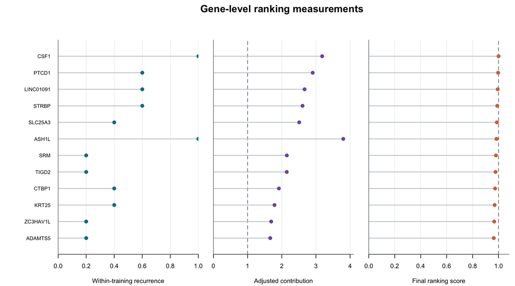

```r
plot_gene_ranking(fit, n = 12)
```

# 6 Biological interpretation

Biological information is assessed after predictive selection. It does not change the gene ranking. Gene Ontology measures functional similarity, Hallmark sets identify shared biological processes, Open Targets records disease associations, and STRING supplies protein-association context. Database coverage and retrieval dates must accompany interpretation. Missing annotation is kept distinct from a measured score of zero.

The package includes the verified biological summaries used to demonstrate the workflow. Ratios compare each selected gene set with same-size random gene sets drawn from the same candidate genes. A value of one denotes the random-set reference. The measurements remain separate because they describe different properties.

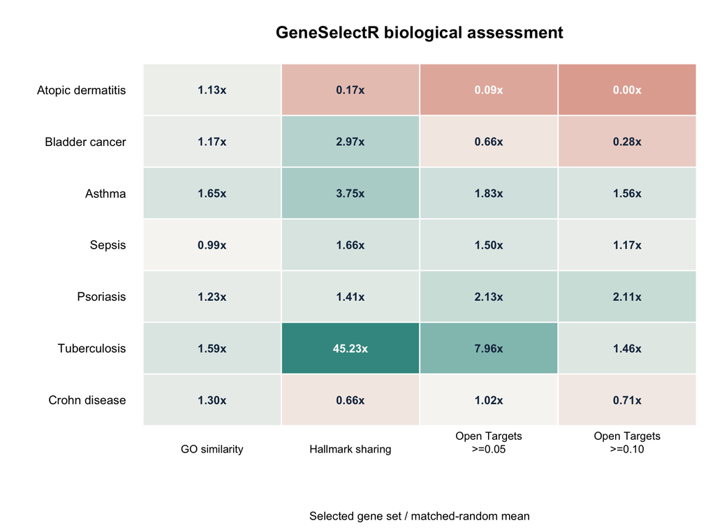

```r
data(benchmark_biology)
plot_biology_comparison(
    benchmark_biology, method = "GeneSelectR",
    dataset_order = c(
        "Atopic dermatitis", "Bladder cancer", "Asthma", "Sepsis",
        "Psoriasis", "Tuberculosis", "Crohn disease"
    )
)
```

For asthma, the selected-to-random ratios were 1.65 for GO similarity, 3.75 for Hallmark sharing, 1.83 for Open Targets at a score cutoff of 0.05, and 1.56 at a cutoff of 0.10. These are descriptive ratios. They are not probabilities, p-values or components of the predictive ranking.

# 7 Full-cohort asthma output

The executable fit above uses 96 samples and 300 genes so that the vignette can be built during package checks. The following figure uses the verified full-cohort GSE69683 results reported in the manuscript: 323 samples, 15 outer validation divisions and sets of 20 genes. This packaged data object lets users inspect and reproduce the display without downloading external databases.

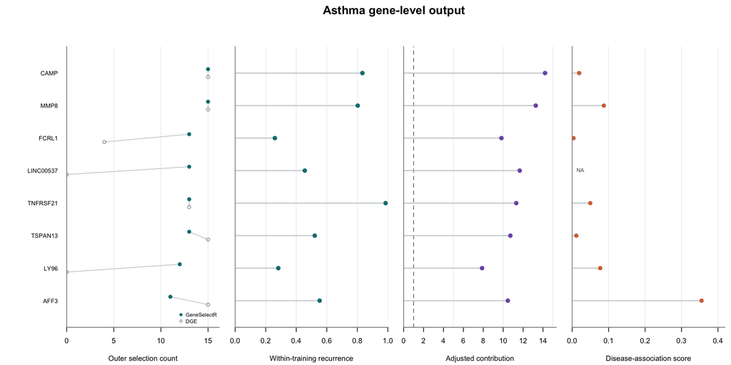

```r
data(asthma_case_study)
plot_gene_evidence(asthma_case_study, comparison_label = "DGE")
```

Outer selection count records membership in each final top-20 gene set. Within-training recurrence records inclusion among the elastic-net fits used to construct a ranking. Adjusted contribution is compared with shuffled-outcome fits. The Open Targets value is a continuous recorded asthma association from release 26.06. `LINC00537` has no available Open Targets score and remains marked `NA`.

# 8 Reproducibility

The example source and deterministic subset rule are documented in `?asthma_example`. Small-sample example results should not be substituted for the full-cohort results in the manuscript. Internal AUC is used for tuning and is not an outer-test performance estimate.